# Cell cycle - Buettner mESC dataset

Fanny Perraudeau

July 12, 2017

```r
NCORES = 2
mysystem = Sys.info()[['sysname']]
if (mysystem == 'Darwin'){
  registerDoParallel(NCORES)
  register(DoparParam())
}else if (mysystem == 'Linux'){
  register(bpstart(MulticoreParam(workers=NCORES)))
}else{
  print('Please change this to allow parallel computing')
  register(SerialParam())
}
```

In paper “Computational analysis of cell-to-cell heterogeneity in single-cell RNA-sequencing data reveals hidden subpopulations of cells” (Buettner et al), they use a dataset with 182 cells and about 9000 genes (fluidigm C1) where they know the cell cycle status of the cells (G1, S, or G2M). Let’s see if we can use this dataset to demonstrate the ability of zinbwave to extract wanted/unwanted variance. We want to show that we can remove unwanted cell-cycle effect.

# Preprocessing

We filter cells and genes as in the paper.

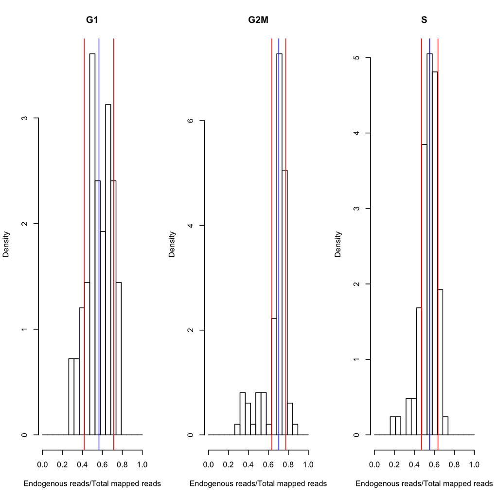

```r
path = 'E-MTAB-2805.processed.1/'
keepgenes = read_excel('keptgenes_buettner_suppldata2.xlsx', sheet = 2)
keepgenes = colnames(keepgenes)
fn = list.files(path)
pal = brewer.pal(9, "Set1")[1:3]
par(mfrow=c(1,3))
counts = lapply(fn, function(y){
  xx = read.table(paste0(path, y), stringsAsFactors = F, header = T)
  tot = unlist(xx[xx$EnsemblGeneID == 'Aligned', 5:ncol(xx)])
  endo = colSums(xx[!grepl('ERCC|Ambiguous|No_feature|Not_aligned|Too_low_aQual|Aligned', xx$EnsemblGeneID), 5:ncol(xx)])
  detected = colSums(xx[1:(nrow(xx)-5), 5:ncol(xx)]!=0)
  percQC = unlist(xx[xx$EnsemblGeneID=='Too_low_aQual', 5:ncol(xx)]) / tot

  mito = read.csv('~/Documents/scRNAseq/scRNAseq-zinbwave/neuroblastoma/data/Mouse.MitoCarta2.0.txt', header = T,
                              sep = '\t', stringsAsFactors = F)
  mito = unique(mito[mito$TrainingDataset %in% c('Tmito'), 'EnsemblGeneID'])
  mito = colSums(xx[xx$EnsemblGeneID %in% mito, 5:ncol(xx)])

  filt = tot < 0.5*10^6 | detected < 6000 | percQC > .1 | mito/endo > .15
  xx = cbind(xx[, 1:4], xx[, 5:ncol(xx)][, !filt])

  ratio = endo/tot
  ratio = ratio[!filt]
  hist(ratio, breaks = seq(0,1,length.out = 20), xlim = c(0,1), freq = F,
       xlab = 'Endogenous reads/Total mapped reads', main = strsplit(y, '_')[[1]][1])
  med = median(ratio)
  mad = mad(ratio)
  abline(v = med, col = 'blue')
  abline(v = med+mad, col = 'red')
  abline(v = med-mad, col = 'red')

  xx = xx[xx$AssociatedGeneName %in% keepgenes, ]
  xx = xx[, c(3, 5:ncol(xx))]
  xx$AssociatedGeneName = factor(xx$AssociatedGeneName)
  xx = stats::aggregate(. ~ AssociatedGeneName, data =  xx, FUN = max)
  rownames(xx) = as.vector(xx$AssociatedGeneName)
  xx = xx[, 2:ncol(xx)]
  xx[, (ratio < med + mad) & (ratio > med - mad)]
})
```

```r
stopifnot(all.equal(rownames(counts[[1]]), rownames(counts[[2]])))
stopifnot(all.equal(rownames(counts[[3]]), rownames(counts[[2]])))
counts = do.call(cbind, counts)
counts = as.matrix(counts)
counts = counts[rowSums(counts>10)>=10, ]
dim(counts)
```

```
## [1] 8332  183
```

```r
cellcycle = sapply(colnames(counts), function(x) strsplit(x, '_')[[1]][1])
table(cellcycle)
```

```
## cellcycle
##  G1 G2M   S
##  57  68  58
```

```r
names(pal) = unique(cellcycle)
```

# Fit zinbwave

```r
eps = ncol(counts)
```

We fit zinbwave with K = 2 and X an intercept only. I tried higher K but results are similar.

```r
set.seed(89303)
print(system.time(zinb <- zinbFit(Y = counts, K = 2, epsilon = eps)))
```

```
##    user  system elapsed
## 456.165  53.113 307.336
```

```r
par(mfrow=c(1,3))
plot(zinb@W, col = pal[cellcycle], main = 'ZINB W, K = 2, X intercept')
legend(x = 'bottomright', legend = names(pal), cex = .5, fill = pal,
       title = 'Known Cell Cycle')

km = kmeans(zinb@W, centers = 3)
labs_k3 = km$cluster
table(labs_k3, cellcycle)
```

```
##        cellcycle
## labs_k3 G1 G2M  S
##       1 14   0  0
##       2 34   1 28
##       3  9  67 30
```

```r
plot(zinb@W, col = labs_k3, main = 'ZINB W, K = 2, X intercept')
legend(x = 'bottomright', legend = unique(labs_k3), cex = .5,
       fill = unique(labs_k3), title = 'Kmeans, k = 3')

km = kmeans(zinb@W, centers = 4)
labs_k4 = km$cluster
table(labs_k4, cellcycle)
```

```
##        cellcycle
## labs_k4 G1 G2M  S
##       1 24   5 50
##       2 18   0  1
##       3  1  63  7
##       4 14   0  0
```

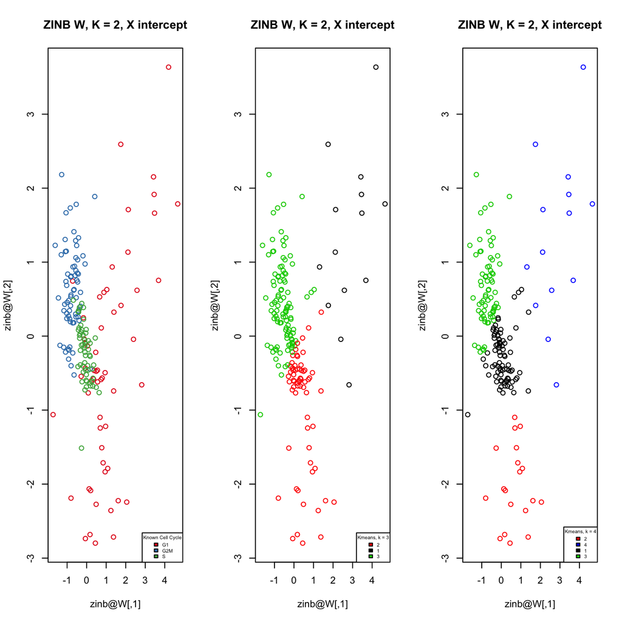

```r
plot(zinb@W, col = labs_k4, main = 'ZINB W, K = 2, X intercept')
legend(x = 'bottomright', legend = unique(labs_k4), cex = .5, fill = unique(labs_k4),
       title = 'Kmeans, k = 4')
```

We have a set of genes known to be associated with cell cycle. What measure could we compute to show that correlation with cell cycle when X = int and no more correlation with cell cycle when x = (int, labs)

```r
ccgenes = read.csv('cellcyclegenes_buettner_suppltable1.csv', stringsAsFactors = F)
ccgenes = ccgenes[,1]
head(ccgenes)
```

```
## [1] "ENSMUSG00000021866" "ENSMUSG00000017716" "ENSMUSG00000007815"
## [4] "ENSMUSG00000034218" "ENSMUSG00000042750" "ENSMUSG00000017146"
```

# Fit zinb using learnt labels

We fit zinb where X = c(int, learnt clusters from kmeans)

```r
X = model.matrix(~ labs_k3)
eps = 10000
print(system.time(zinb_learnt_k3 <- zinbFit(Y = counts, K = 2, X = X, epsilon = eps)))
```

```
##    user  system elapsed
## 535.783  57.600 330.053
```

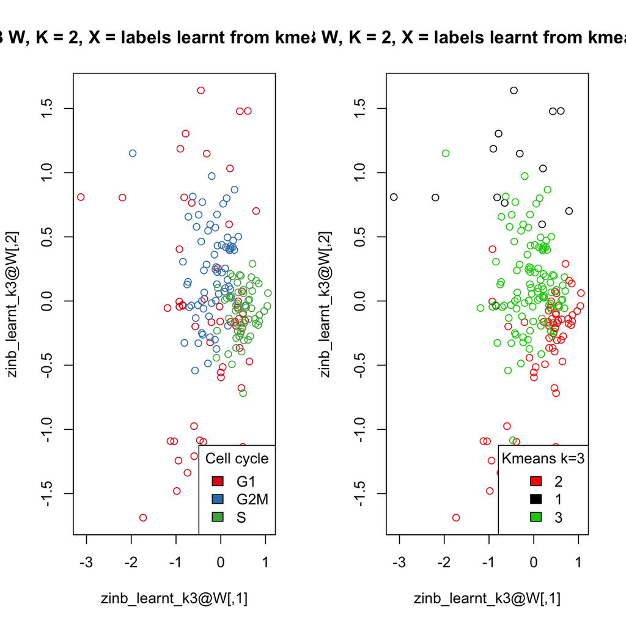

```r
par(mfrow = c(1,2))
main = 'ZINB W, K = 2, X = labels learnt from kmeans k = 3'
plot(zinb_learnt_k3@W, col = pal[cellcycle], main=main)
legend(x = 'bottomright', legend = names(pal), fill = pal, title = 'Cell cycle')
plot(zinb_learnt_k3@W, col = labs_k3, main = main)
legend(x = 'bottomright', legend = unique(labs_k3), fill = unique(labs_k3),
       title = 'Kmeans k=3')
```

```r
X = model.matrix(~ labs_k4)
print(system.time(zinb_learnt_k4 <- zinbFit(Y = counts, K = 2, X = X, epsilon = eps)))
```

```
##    user  system elapsed
## 514.602  58.805 327.252
```

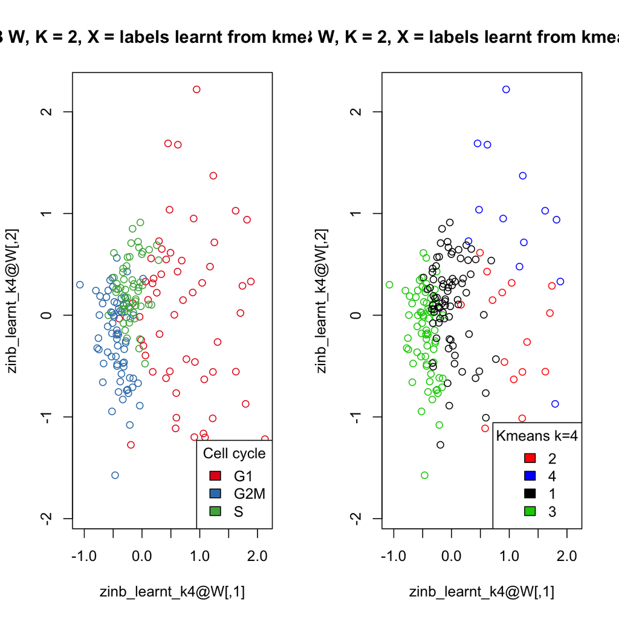

```r
par(mfrow = c(1,2))
main = 'ZINB W, K = 2, X = labels learnt from kmeans k = 4'
plot(zinb_learnt_k4@W, col = pal[cellcycle], main=main)
legend(x = 'bottomright', legend = names(pal), fill = pal, title = 'Cell cycle')
plot(zinb_learnt_k4@W, col = labs_k4, main = main)
legend(x = 'bottomright', legend = unique(labs_k4), fill = unique(labs_k4),
       title = 'Kmeans k=4')
```

# Fit zinb using known cell cycle status

We fit zinb where X = c(int, known cell cycle status)

```r
X = model.matrix(~ cellcycle)
print(system.time(zinb_known_cl <- zinbFit(Y = counts, K = 2, X = X, epsilon = eps)))
```

```
##    user  system elapsed
## 675.622  75.630 435.230
```

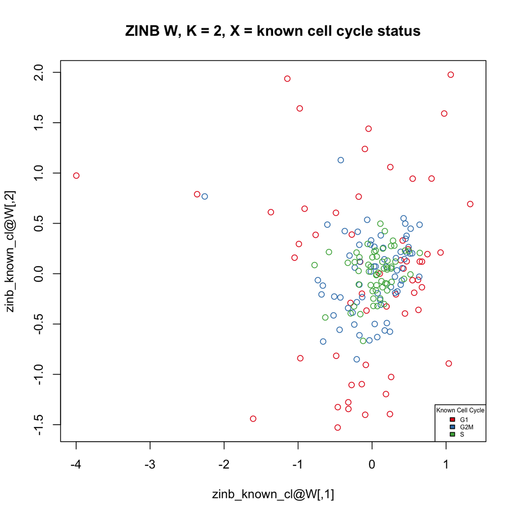

```r
plot(zinb_known_cl@W, col = pal[cellcycle], main = 'ZINB W, K = 2, X = known cell cycle status')
legend(x = 'bottomright', legend = names(pal), cex = .5, fill = pal,
       title = 'Known Cell Cycle')
```

# Length bias

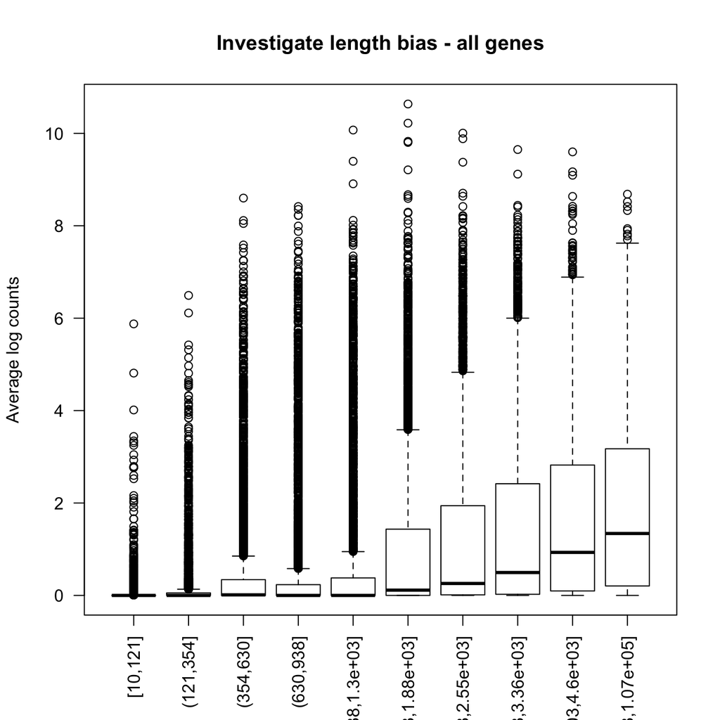

```r
xx = read.table(paste0(path, fn[1]), stringsAsFactors = F, header = T)
len = xx[,'GeneLength']
names(len) = xx[,'EnsemblGeneID']

aveLogCounts = Matrix::rowMeans(log1p(xx[1:(nrow(xx)-97),
                                         colnames(xx) %in% colnames(counts)]))
len_bins = cut_number(xx$GeneLength[1:(nrow(xx)-97)], 10)
boxplot(aveLogCounts ~ len_bins, las=2, main = 'Investigate length bias - all genes',
        ylab = 'Average log counts')
```

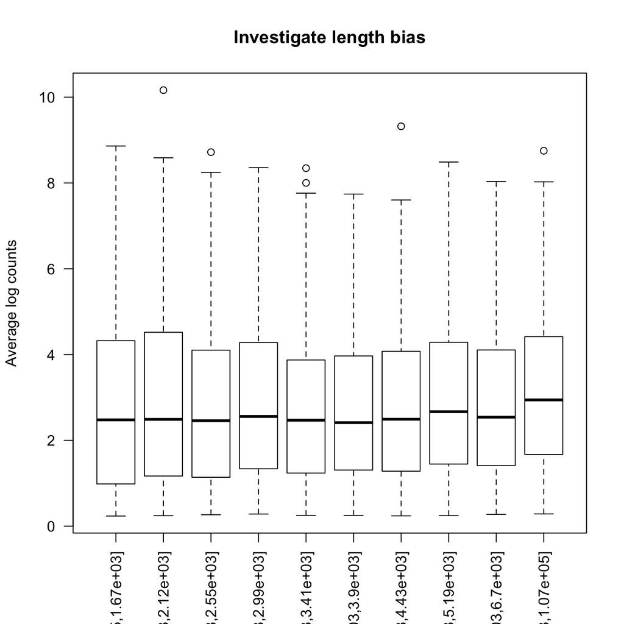

```r
xx = read.table(paste0(path, fn[1]), stringsAsFactors = F, header = T)
xx = xx[, c('AssociatedGeneName', 'GeneLength')]
xx = xx[xx$AssociatedGeneName %in% rownames(counts), ]
xx$AssociatedGeneName = factor(xx$AssociatedGeneName)
xx = stats::aggregate(GeneLength ~ AssociatedGeneName, xx, mean)
len = xx[,2]
names(len) = xx[,1]
len = len[rownames(counts)]
aveLogCounts = Matrix::rowMeans(log1p(counts))
len_bins = cut_number(len, 10)
boxplot(aveLogCounts ~ len_bins, las=2, main = 'Investigate length bias',
        ylab = 'Average log counts')
```

```r
set.seed(89303)
V = model.matrix( ~ log(len))
print(system.time(zinb_len <- zinbFit(Y = counts, K = 2, V = V, epsilon = eps)))
```

```
##    user  system elapsed
## 483.589  58.106 315.130
```

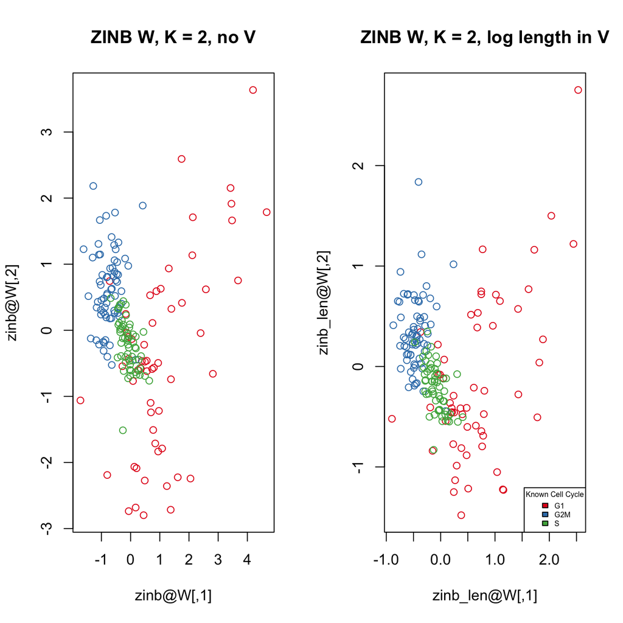

```r
par(mfrow = c(1,2))
plot(zinb@W, col = pal[cellcycle], main = 'ZINB W, K = 2, no V')
plot(zinb_len@W, col = pal[cellcycle], main = 'ZINB W, K = 2, log length in V')
legend(x = 'bottomright', legend = names(pal), cex = .5, fill = pal,
       title = 'Known Cell Cycle')
```

```r
par(mfrow=c(1,2))
plot(zinb_len@W, col = pal[cellcycle], main = 'ZINB W, K = 2, X intercept')
legend(x = 'bottomright', legend = names(pal), cex = .5, fill = pal,
       title = 'Known Cell Cycle')

km = kmeans(zinb_len@W, centers = 3)
labs_k3 = km$cluster
table(labs_k3, cellcycle)
```

```
##        cellcycle
## labs_k3 G1 G2M  S
##       1 19   0  0
##       2 32   1 28
##       3  6  67 30
```

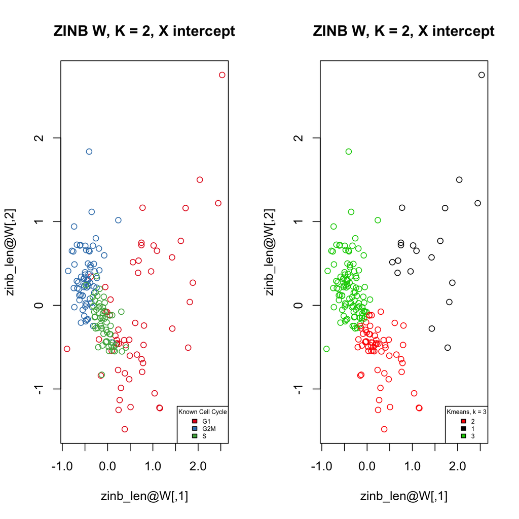

```r
plot(zinb_len@W, col = labs_k3, main = 'ZINB W, K = 2, X intercept')
legend(x = 'bottomright', legend = unique(labs_k3), cex = .5,
       fill = unique(labs_k3), title = 'Kmeans, k = 3')
```

```r
X = model.matrix(~ labs_k3)
print(system.time(zinb_learnt_k3 <- zinbFit(Y = counts, K = 2, X = X, V=V, epsilon = eps)))
```

```
##    user  system elapsed
## 526.451  62.769 338.721
```

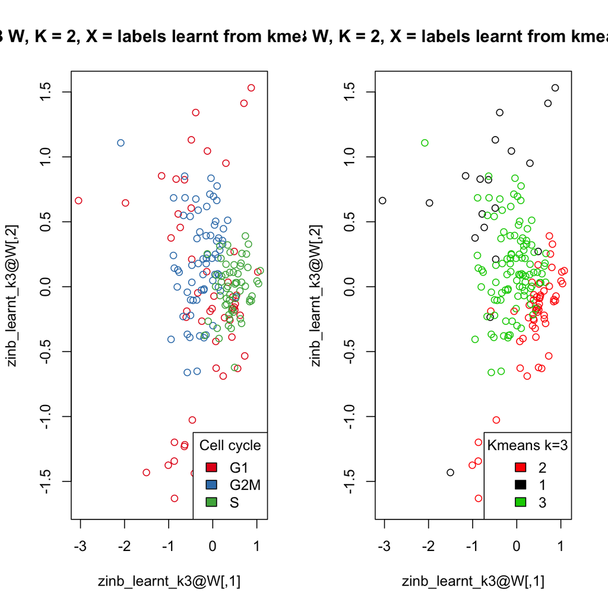

```r
par(mfrow = c(1,2))
main = 'ZINB W, K = 2, X = labels learnt from kmeans k = 3'
plot(zinb_learnt_k3@W, col = pal[cellcycle], main=main)
legend(x = 'bottomright', legend = names(pal), fill = pal, title = 'Cell cycle')
plot(zinb_learnt_k3@W, col = labs_k3, main = main)
legend(x = 'bottomright', legend = unique(labs_k3), fill = unique(labs_k3),
       title = 'Kmeans k=3')
```